# Inference about the bias of a coin

Giorgio Corani

Bayesian Data Analysis and Probabilistic Programming

# The coin problem

# The coin problem

- The coin stands in for a real-world application, such as estimating the success probability of a drug, the probability of a person being left handed, etc

**Assumptions**

- Each observation can take only binary values (success / insuccess)
- Each observation is independent from the others: the probability of getting *heads* at the next flip does not depend on the outcome of the previous flip
- $\theta$ is constant in all flips.

# The coin problem

A single flip takes:

- *heads* with probability $\theta$
- *tails* with probability $1-\theta$
- Under the previous assumptions, the probability of the sequence:
  $$H \quad T \quad T \quad H \quad
  H$$
- is $\theta^2 (1-\theta)^3$
- A sequence of length $n$, containing $y$ heads, has probability
  $$\theta^y (1-\theta)^{n-y}$$

# Binomial Likelihood function for a set of binary flips

$$p(y \mid \theta) = \theta^y (1 −
\theta)^{1−y}$$

# The prior $p(\theta)$

- We need to define the prior probability of each value of $\theta$ in $[0, 1]$.
- The beta distribution, denoted by $\text{Beta}(a, b)$, is a suitable prior for variables restricted to the $[0, 1]$ interval.
- The density function is:

$$\begin{align*}
p(\theta) & =
\frac{1} {\underbrace{B(a,b)}_{\text{normalizing constant}}}
\theta^{a-1}(1-\theta)^ {b-1}
\propto \theta^{a-1}(1-\theta)^ {b-1} \qquad \qquad a,b>0
\end{align*}$$

- Let us ignore the normalizing constant.

Note that:

- $\theta$ is raised to the power of $a−1$ (not $a$)
- $1-\theta$ is raised to the power of $b−1$ (not $b$)

# Beta distribution

- Expectation (i.e., mean):
  $$E(\theta)=
  \frac{a}{a+b}$$
- Variance:
  $$\operatorname{VAR}(\theta)=
  \frac{ab}{(a+b)^2(a+b+1)}$$
- Higher $a$: the bulk of the distribution moves rightward
- Higher $b$: the bulk of the distribution moves leftward
- Higher $a$ and $b$: the distribution gets more concentrated.

# Beta distribution with $a = b = 1$

$$\begin{align*}
p(\theta) & \propto \theta^{a-1}(1-\theta)^ {b-1} \\
& = \theta^{0}(1-\theta)^ {0} \\
& = 1
\end{align*}$$

- This a *uniform* distribution: all values in $(0,1)$ are equally probable.
- $E(\theta)=\frac{a}{a+b} = 0.5$.

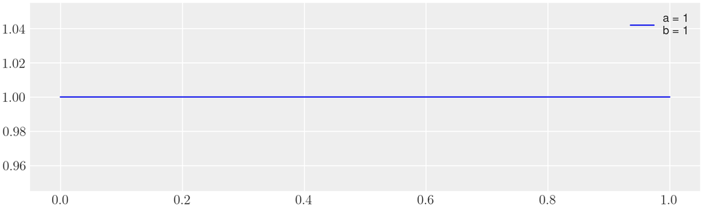

# Increasing $a$ and $b$ the prior becomes more concentrated

- If we increase $a$ and $b$ together, the prior becomes more concentrated around the expected value $\theta=0.5$
- We can thus represent more confident beliefs about the coin being fair

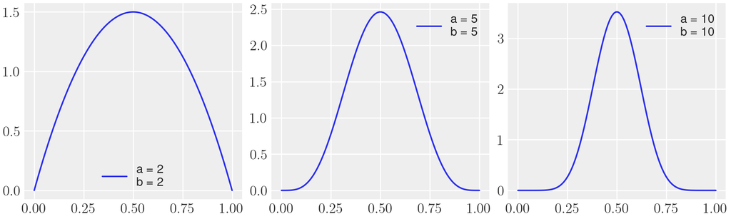